# RED WINE ANALYSIS BY TEAGAN BLACK

# Bivariate Plots Section

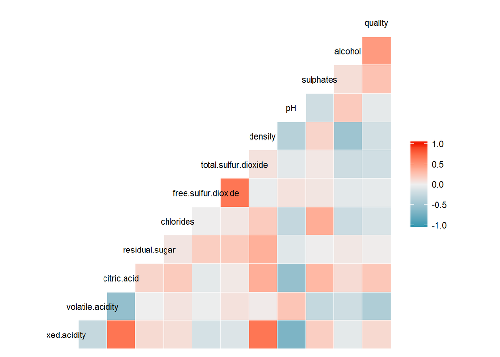

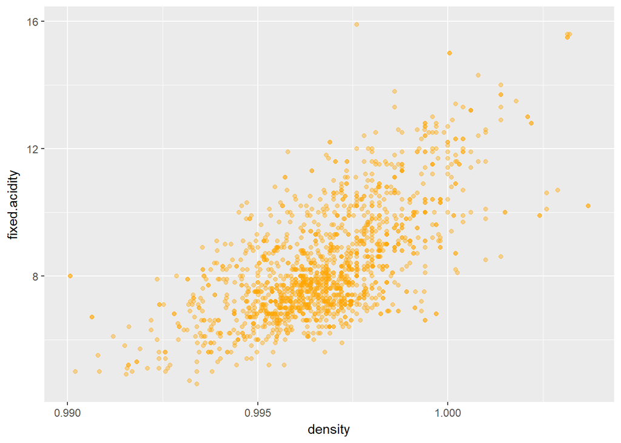

Looking at fixed.acidity versus density, we can see there is what seems to be a linear relationship, although the data seems overfitted. Some alpha was added to try see through this. There also seemed to be a relationship between citric acid and fixed acidity.

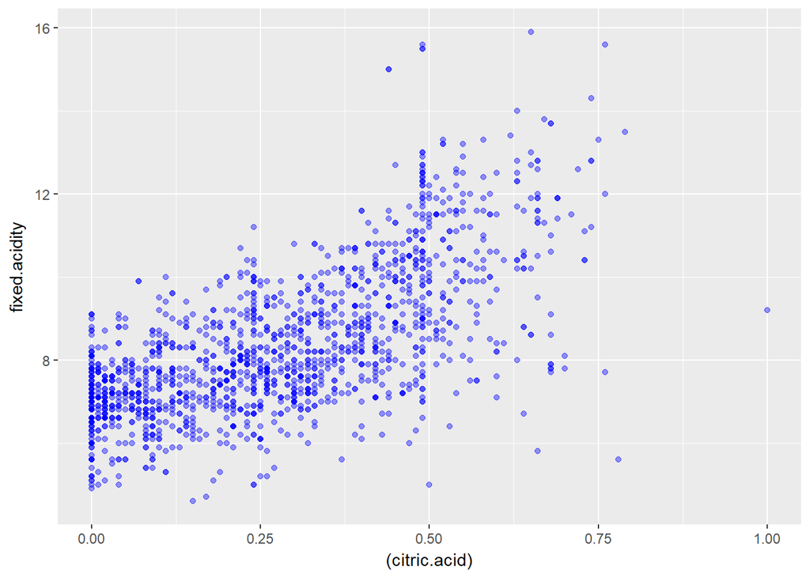

This relationship seems less clear than the density one. There could perhaps be a non- linear relationship. Let’s see if we can use a transformation to get a more linear shape.

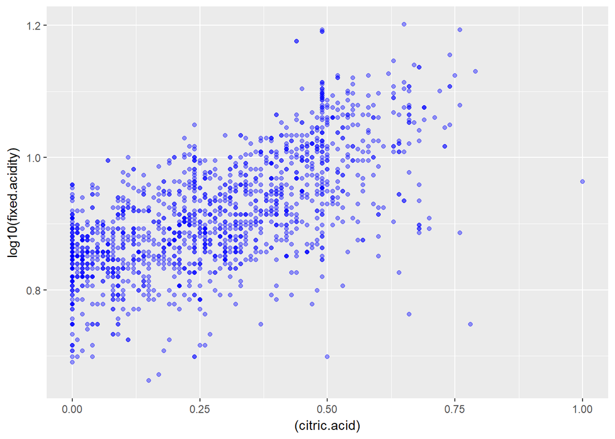

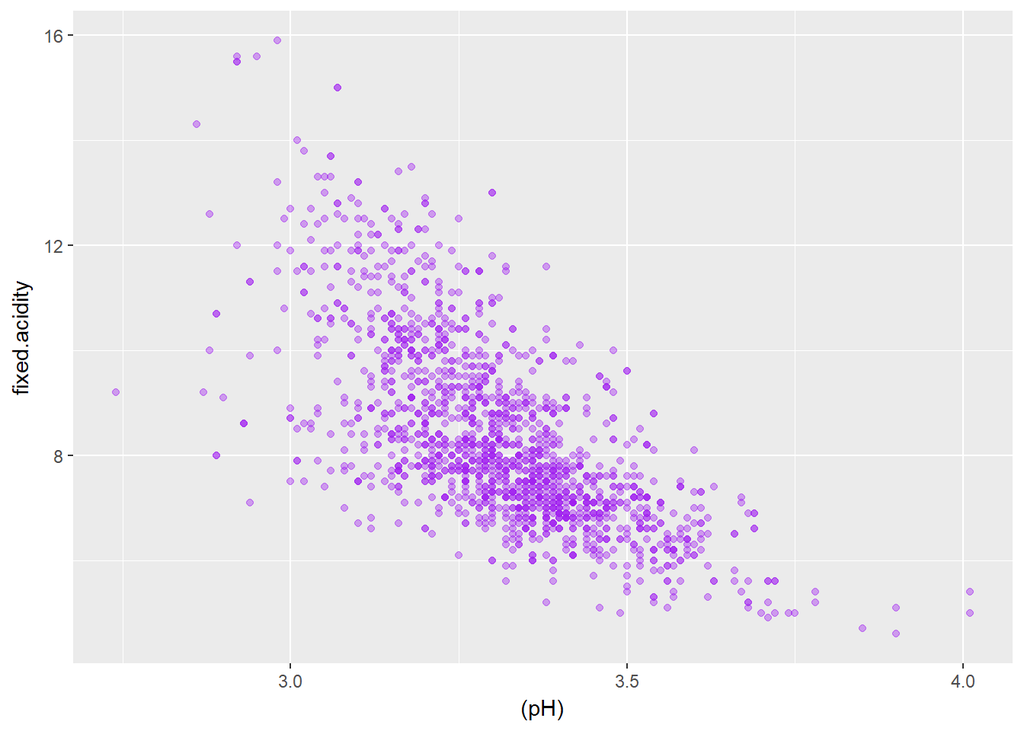

This also produces a non-linear shape so let’s try a transform

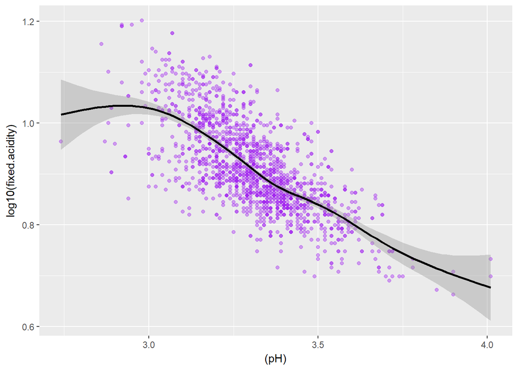

Again, this is more linear. It would be interesting to see if we could build a model to predict fixed acidity. Adding in a smooth line to see the trend, it looks like our data is fairly consistent in the middle but then gets distorted by extremes. It would be useful if we could predict quality so let’s look at some of the relationships of the various qualities with quality.

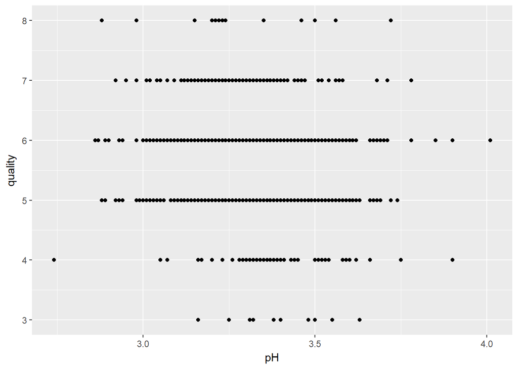

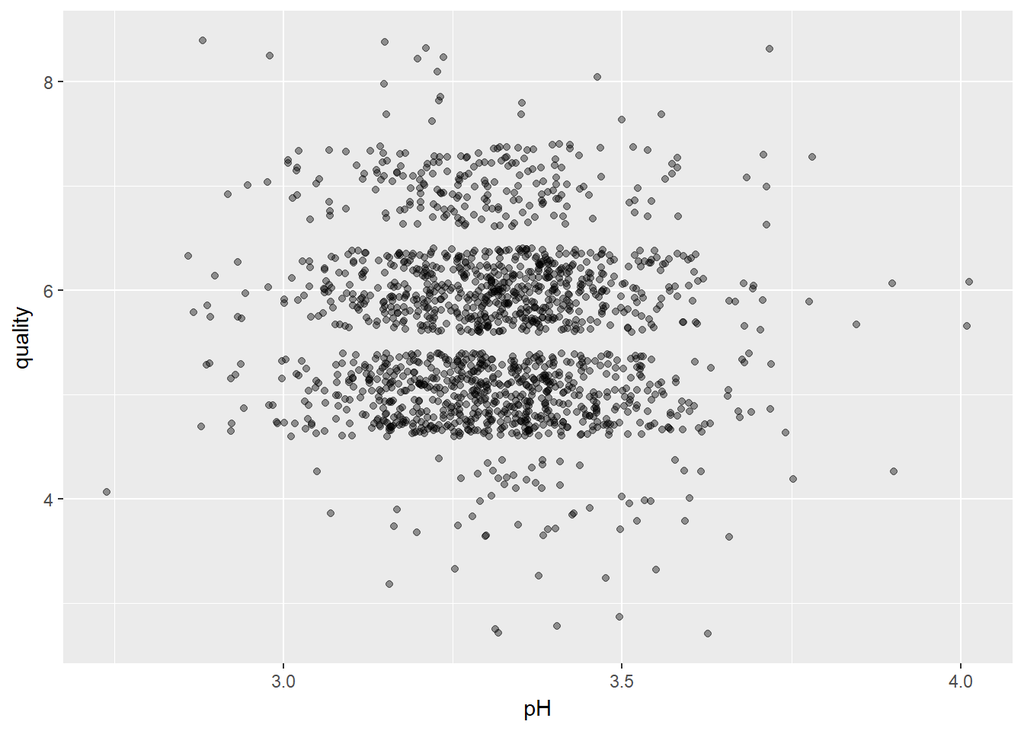

Looking at pH versus quality, it does not appear to be any obvious relationship. THe data suffers from having most data point of quality 5 or 6. The first graph suffers from over-fitting, so adding in some alpha and jitter gives a better graph. Looking at the few data points for quality 3 and 8 shows that it could lower pH leads to a better quality. Alcohol had some promising patterns in the ggpairs - let’s look at that

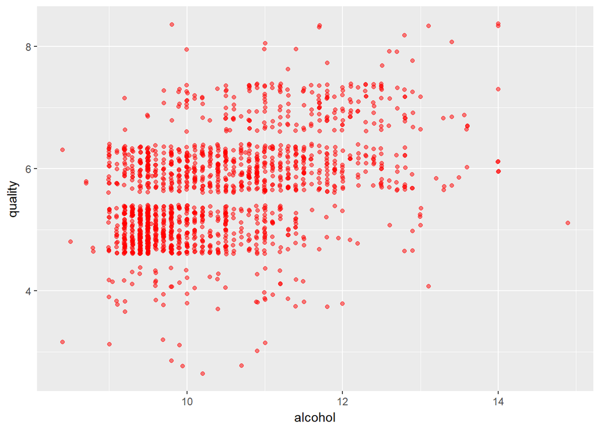

Again using some jitter to try see through the discreteness of quality, it looks like there could be a weak relationship between alcohol and quality. I have heard wine drinkers talk about the sulphate content in wine, so I wonder if that has any link to quality?

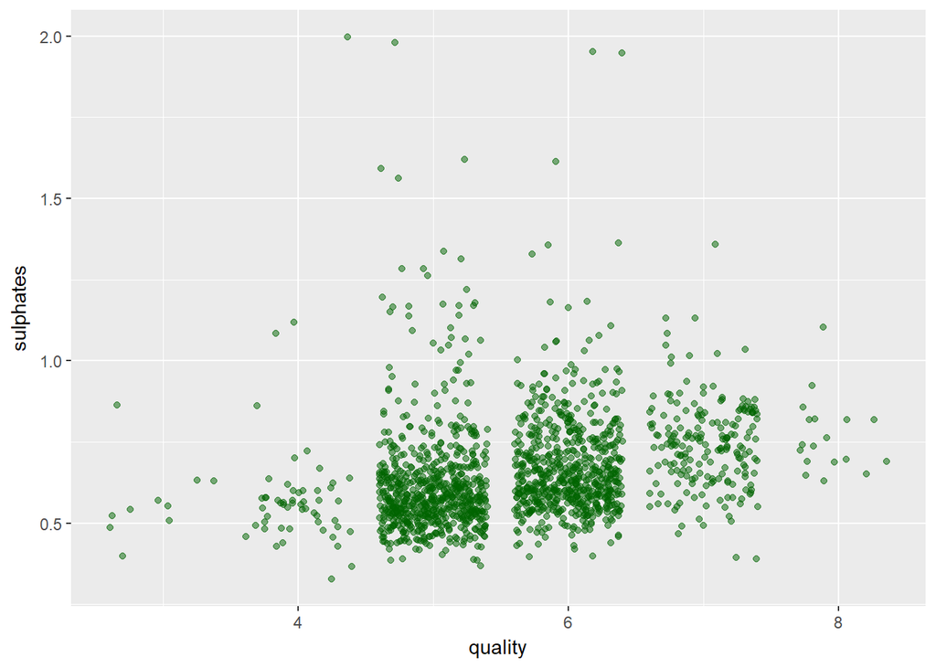

It does seem like there could be a relationship but the data is tightly bunched. Let’s exclude some of the extremes

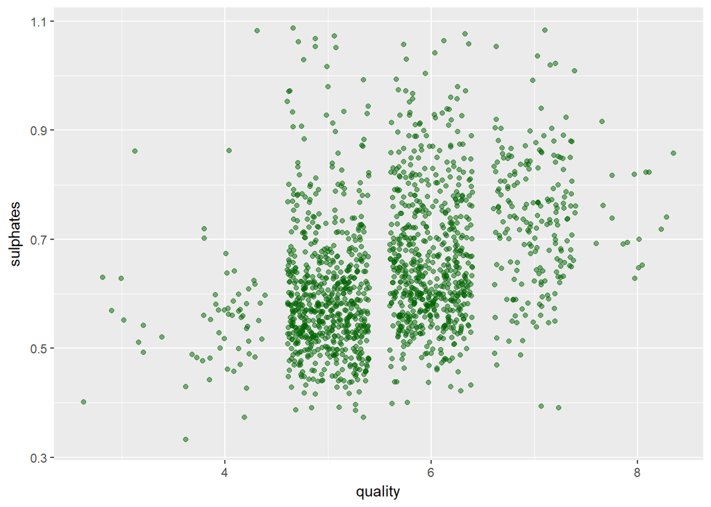

That is better - it definitely seems like there could be a vague linear relationship here.

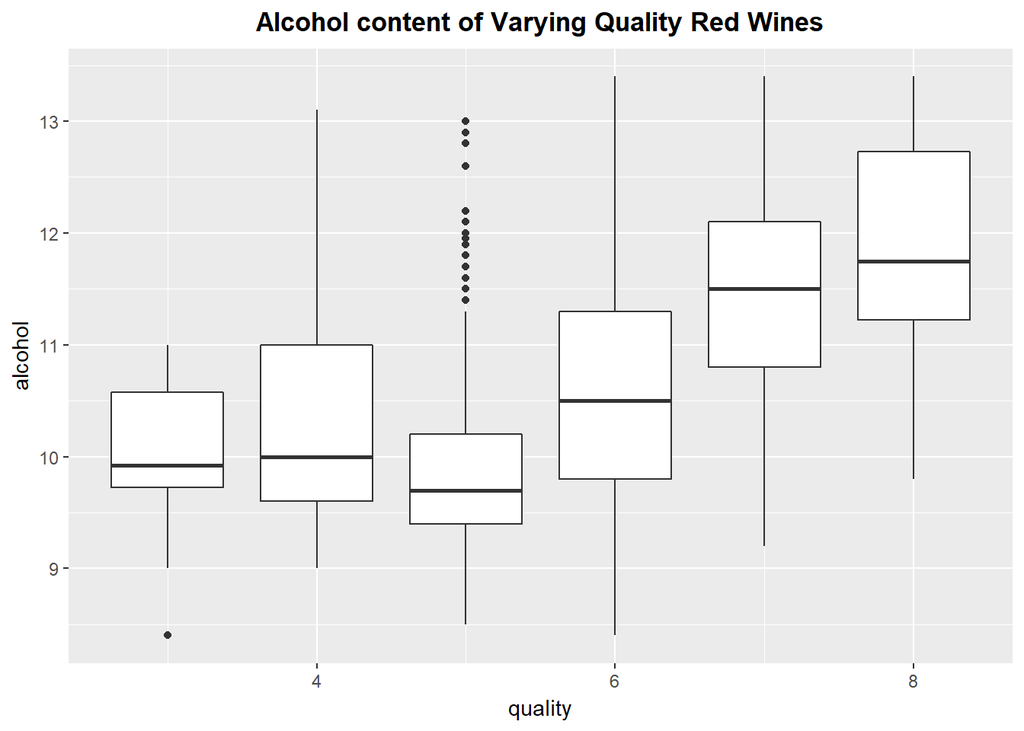

It seems that a higher average alcohol content leads to better wine but it is noticeable that this does not hold true for lower quality wines.

# Bivariate Analysis

### Did you observe any interesting relationships between the other features (not the main feature(s) of interest)?

What was unexpectedly interesting was the relationship between fixed acidity and density, pH and citric acid. There seems an almost linear relationship between the log of fixed acidity and those three characteristics

### What was the strongest relationship you found?

Between fixed acidity and citric acid (0.6 correlation coefficient)

# Multivariate Plots Section

It seemed like there were many relationships between fixed acidity and other qualities so I am going to try build a clearer picture of fixed acidity.

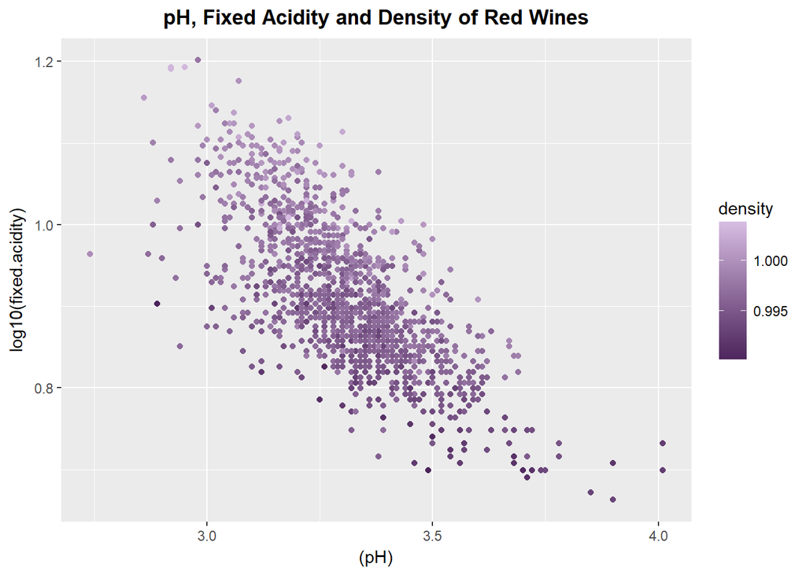

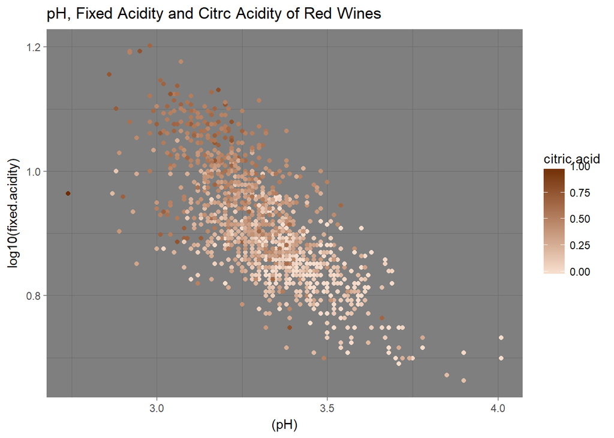

Looking at fixed acidity, pH and citric acid, it seems the lower the citric acid, the lower the log of fixed acidity but across all pHs. Density also has a similar pattern. I wonder what this will look like cut by quality

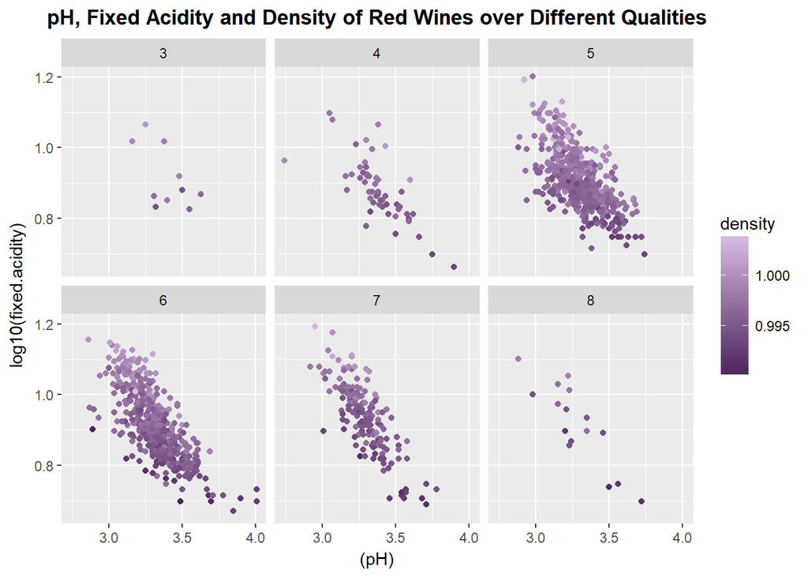

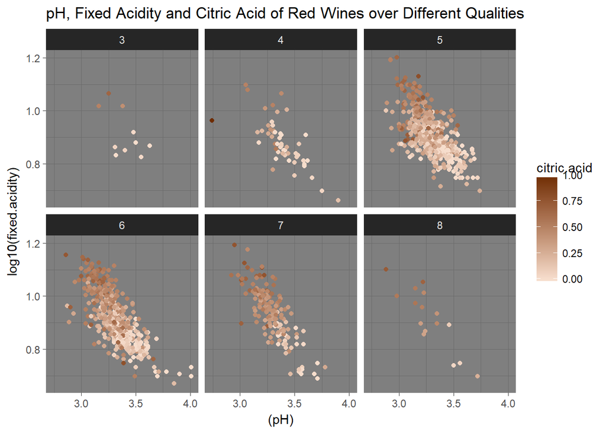

Whilst the relationship between quality and the other characteristics seems weak, there is definitely some correlation between fixed acidity and pH, density and citrc acid so let’s try build a model.

```
##
## Calls:
## m1: lm(formula = I(log10(fixed.acidity)) ~ I(pH), data = wine)
## m2: lm(formula = I(log10(fixed.acidity)) ~ I(pH) + citric.acid, data = wine)
## m3: lm(formula = I(log10(fixed.acidity)) ~ I(pH) + citric.acid +
##     density, data = wine)
##
## ============================================================
##                        m1            m2            m3
## ------------------------------------------------------------
##   (Intercept)         2.223***      1.769***    -18.097***
##                      (0.033)       (0.036)       (0.607)
##   I(pH)              -0.396***     -0.274***     -0.225***
##                      (0.010)       (0.010)       (0.008)
##   citric.acid                       0.179***      0.130***
##                                    (0.008)       (0.007)
##   density                                        19.781***
##                                                  (0.603)
## ------------------------------------------------------------
##   R-squared           0.499         0.613         0.769
##   adj. R-squared      0.499         0.613         0.769
##   sigma               0.061         0.054         0.042
##   F                1590.273      1266.373      1770.659
##   p                   0.000         0.000         0.000
##   Log-likelihood   2195.919      2403.337      2815.227
##   Deviance            6.005         4.633         2.768
##   AIC             -4385.839     -4798.674     -5620.455
##   BIC             -4369.707     -4777.166     -5593.569
##   N                1599          1599          1599
## ============================================================
```

Looking at the R squared value, these three variables account for 77% of the variability in fixed volatility. Trying to add other variables does not significantly change this so I will leave the model here.

# Multivariate Analysis

### Were there any interesting or surprising interactions between features?

The facet wrap graphs confirmed my suspicions that quality was quite unrelated to the changes in fixed acidity, citric acid and pH.

### OPTIONAL: Did you create any models with your dataset? Discuss the strengths and limitations of your model.

Yes, I created a model. The model is strong in that it is based on a large sample size but could only be used for Portguese wines from the Vinoh Verde grape and even then will still only predict with an R- squared of 0.77, which is not very accurate. ——

# Final Plots and Summary

### Plot One

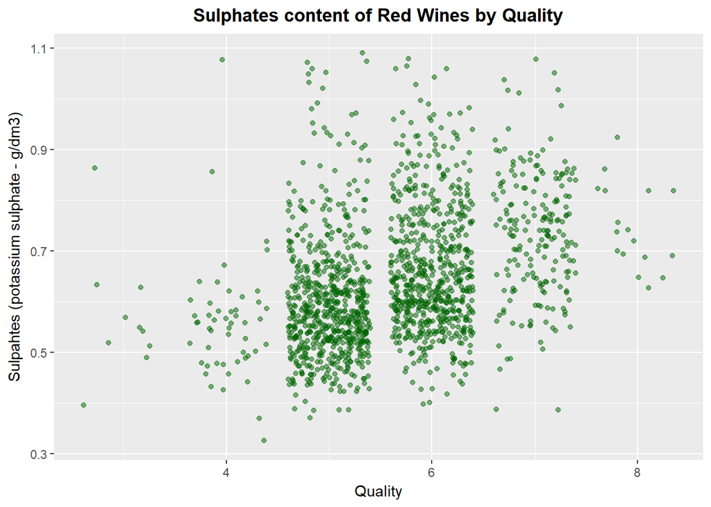

### Description One

This plot is interesting as it was one of the clearest indicators of quality, even though it is not actually very clear. Because of the discreteness of the quality, jitter was used to try “see” a more spread out pattern. It also demonstrates the extreme concentration of data points on wines of quality 5 and 6. It is also perhaps a reflection of what I hoped to achieve when starting this - to find a model to predict quality. What I ended up with was mostly plots like this but some clearer plots on fixed acidity!